# Topic Proposal

2023-03-09

I. Introduction

Artificial Intelligence has made great strides in its adoption across multiple private and public sector use cases. While technologists and investors have continued to push for further development and deployment of automated systems, public opinion around AI is vastly polarized along many key categories such as one’s race, age, class and gender. A common fear surrounds the public’s mistrust in the abilities of an automated decision making tool to ensure fairness, justice and transparency in high-stakes decisions such as pre-trial detention or hiring.

In this project, I hope to explore the variation in public attitudes regarding the risk of AI having harmful consequences. I want to specifically look at how do attitudes change across race, gender, education or age, determine their support for or concerns with such technologies.

The data I’ll be using to explore these questions come is stated below:

Zhang, Baobao; Dafoe, Allan, 2019, “Replication Data for: Artificial Intelligence: American Attitudes and Trends (January 9, 2019)”, https://doi.org/10.7910/DVN/SGFRYA, Harvard Dataverse, V1, UNF:6:XASNQjh6L8LmDwZVrXw4Iw== [fileUNF]

Specifically, the data comes from a report conducted by The Center for the Governance of AI at the University of Oxford. https://governanceai.github.io/US-Public-Opinion-Report-Jan-2019/

They contracted their data collection out to YouGov, an organization which specializes in qualitative research and public opinion surveys. YouGov interviewed 2,387 respondents which was then matched down to 2,000 observations within their data set. The matching was done to based on a sample from the 2016 American Community Survey, accounting for representation of variables such as on gender, age, race and education.

The variables this data set looks at are many, but for the sake of my project, I will be considering the following variables:

1- “Q1_9”: Likelihood of event globally in next 10 years - Harmful consequences of artificial intelligence

2- “Q2_9”: Size of negative impact if event occurred - Harmful consequences of artificial intelligence

3- “educ”: Education

4- “gender”: Gender

5- “birthyr”: Birth Year

6- “race”: Race

```r
#Load Packages
library(tidyverse)
library(tidytuesdayR)
library("haven")
library(dataReporter)
#Get data
df0 <- read_sav("YALE0065_OUTPUT.sav")
df1 = subset(df0, select = c(race, educ, birthyr, gender, Q1_9, Q2_9  ) )
```

```r
#Make Codebook
makeDataReport(df1, vol = "6")
```

```
## The default of 'doScale' is FALSE now for stability;
##   set options(mc_doScale_quiet=TRUE) to suppress this (once per session) message
```

```
## Data report generation is finished. Please wait while your output file is being rendered.
```

2. Data analysis

A. Key Variables

1- “Q1_9”: Likelihood of event globally in next 10 years - Harmful consequences of artificial intelligence This variable measures the participant’s opinion on the immediacy of harms that may come from AI The observations are as follows: Count Code Label —– —- —– 65 1 Very unlikely < 5% 92 2 Unlikely 5-20% 89 3 Somewhat unlikely 20-40% 115 4 Equally likely as unlikely 40-60% 65 5 Somewhat likely 60-80% 46 6 Likely 80-95% 45 7 Very likely > 95% 56 8 I don’t know 0 98 skipped 1427 99 not asked

2- “Q2_9”: Size of negative impact if event occurred - Harmful consequences of artificial intelligence This variable measures the degree of harm that could come from AI. The observations are as follows:

```
    Count Code Label
    ----- ---- -----
       43    1 Minimal
       79    2 Minor
      160    3 Moderate
      125    4 Severe
       82    5 Catastrophic
       84    6 I don't know
        0    8 skipped
     1427    9 not asked
```

3- “educ”: Education Count Code Label —– —- —– 125 1 No HS 617 2 High school graduate 422 3 Some college 223 4 2-year 392 5 4-year 221 6 Post-grad 0 8 skipped 0 9 not asked 4- “gender”: Gender Count Code Label —– —- —– 952 1 Male 1048 2 Female 0 8 skipped 0 9 not asked

5- “birthyr”: Birth Year This is simply the year of birth - as a numeric value.

6- “race”: Race

```
    Count Code Label
    ----- ---- -----
     1289    1 White
      236    2 Black
      310    3 Hispanic
       75    4 Asian
       15    5 Native American
       43    6 Mixed
       26    7 Other
        6    8 Middle Eastern
        0   98 skipped
        0   99 not asked
```

B. Preliminary Data Analysis

```r
# Summary statistics for df1
summary(df1)
```

```
##       race            educ          birthyr         gender           Q1_9
##  Min.   :1.000   Min.   :1.000   Min.   :1927   Min.   :1.000   Min.   : 1.00
##  1st Qu.:1.000   1st Qu.:2.000   1st Qu.:1956   1st Qu.:1.000   1st Qu.: 7.00
##  Median :1.000   Median :3.000   Median :1972   Median :2.000   Median :99.00
##  Mean   :1.777   Mean   :3.401   Mean   :1971   Mean   :1.524   Mean   :71.81
##  3rd Qu.:2.000   3rd Qu.:5.000   3rd Qu.:1986   3rd Qu.:2.000   3rd Qu.:99.00
##  Max.   :8.000   Max.   :6.000   Max.   :2000   Max.   :2.000   Max.   :99.00
##       Q2_9
##  Min.   :1.000
##  1st Qu.:6.000
##  Median :9.000
##  Mean   :7.469
##  3rd Qu.:9.000
##  Max.   :9.000
```

```r
#Here I can see the range of observations for all the variables. For eg: race has 8 types of observations from 1-8, each denoting a specific race i.e. white or black, etc.

#However, when looking at the the actual prompts of Q1_9 and Q2_9, the observation of 9 denotes that the question was not asked to this group. I will need to filter these answers out as they do not necessarily mean a lot in terms of the individuals opinion.

#Beyond this, there appears to be variation in the data which is a good sign for analysis later on.
```

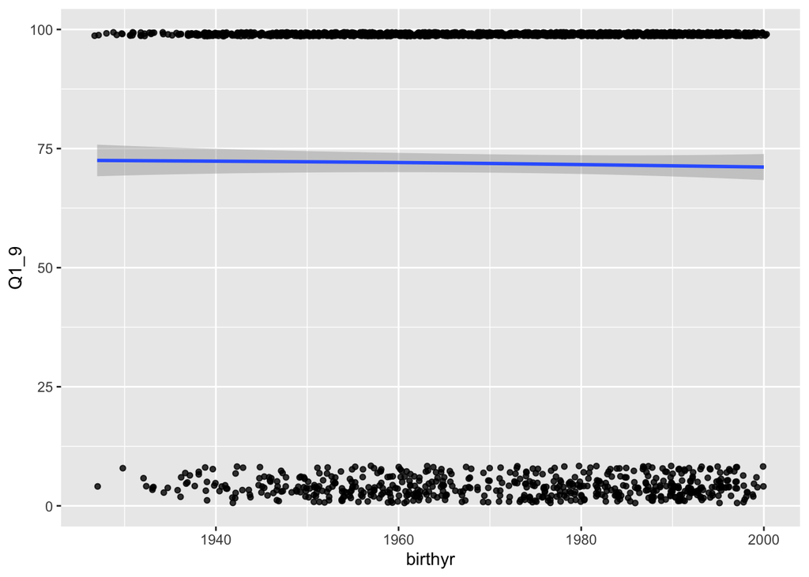

```r
#Plots
q19 <- df1 %>%
  ggplot(data=df1,mapping= aes(x= birthyr, y=Q1_9))+
geom_jitter(alpha=0.8, size=1.3)+
geom_smooth()

q19 #Here we can see how we need to remove the 98 and 99 values as they do not help in viz.
```